# ADS Project 4 Team12

Kexin Nie, Kai Chen, Senyao Han, Yini Zhang, Chenyun Zhu

April 13, 2017

# Introduction

# Part I Simple Linear Support Vector Machine

SVM is one of the most popular tools of classification. In paper 2, the author introduced the use of simple linear svm for a multi-classification. They first divided the data set into test and training set by seperating data with same label into two groups with same size. Then they calculate the test prediction errors. The accuracy rate is simply the porpotion of right match in the test set. For the features selection, since the author of paper doesn’t point out a specific way to choose features, we decide to use the sample code on Github. Also, at the end we caculated the mean and standard deviation of accuracy of all our data set and compared the performance of variable Coauthor, Paper and Journal. ## 1.0 Packages Install

```r
install.packages("pacman")
pacman::p_load(text2vec, dplyr, qlcMatrix, kernlab, knitr)
install.packages("e1071")
```

## 1.1 Input data and feature selection

```r
library(e1071)
library(pacman)
#Our feature fuction
get_feature<-function(data, condition="combine"){
  if (condition=="coauthor"){
    it_train <- itoken(data$Coauthor,
                       preprocessor = tolower,
                       tokenizer = word_tokenizer,
                       ids = data$PaperID,
                       # turn off progressbar because it won't look nice in rmd
                       progressbar = FALSE)
  }else if(condition=="paper"){
    it_train <- itoken(data$Paper,
                       preprocessor = tolower,
                       tokenizer = word_tokenizer,
                       ids = data$PaperID,
                       # turn off progressbar because it won't look nice in rmd
                       progressbar = FALSE)
  } else if(condition=="journal"){
    it_train <- itoken(data$Journal,
                       preprocessor = tolower,
                       tokenizer = word_tokenizer,
                       ids = data$PaperID,
                       # turn off progressbar because it won't look nice in rmd
                       progressbar = FALSE)
  } else{
    combine<-paste(data$Paper, data$Coauthor, data$Journal)
    it_train <- itoken(combine,
                       preprocessor = tolower,
                       tokenizer = word_tokenizer,
                       ids = data$PaperID,
                       # turn off progressbar because it won't look nice in rmd
                       progressbar = FALSE)
  }

  vocab <- create_vocabulary(it_train, stopwords = c("a", "an", "the", "in", "on",
                                                     "at", "of", "above", "under"))
  #vocab
  vectorizer <- vocab_vectorizer(vocab)
  dtm_train <- create_dtm(it_train, vectorizer)
  tfidf <- TfIdf$new()
  dtm_train_tfidf <- fit_transform(dtm_train, tfidf)
  docsdissim <- cosSparse(t(dtm_train_tfidf))
  y<-as.data.frame(as.matrix(docsdissim))
  y$label<-as.factor(data$AuthorID)
  return(y)
  #result_sclust <- specc(as.matrix(dtm_train_tfidf),
  # centers=length(unique(data$AuthorID)))
  #return(result_sclust)

}

my.dir<-"../output/Coauthor_No_Space_Author"
files<-list.files(my.dir)
path<-file.path(my.dir, files)
n<-length(path)
names<-gsub(".csv", "", files)

Data<-list()
n<-1
for (i in path){
  Data[[n]]<-read.csv(i, header = T, stringsAsFactors = FALSE)
  n<-n+1
}

feature_paper<-list()
feature_coauthor<-list()
feature_journal<-list()
feature_combine<-list()
feature_paper<-lapply(Data, get_feature, condition="paper")
feature_coauthor<-lapply(Data, get_feature, condition="coauthor")
feature_journal<-lapply(Data, get_feature, condition="journal")
feature_combine<-lapply(Data, get_feature)

feature_coauthor[is.na(feature_coauthor)]<-0
feature_combine[is.na(feature_combine)]<-0
```

```r
entity<-function(data){
  en<-nrow(data)/length(unique(data$AuthorID))
  return(en)
}
```

```r
mean_entity<-lapply(Data, entity)
mean_entity<-unlist(mean_entity)
```

## 1.2 Linear SVM

To understand the basic idea of svm, please visit: http://www.cs.columbia.edu/~kathy/cs4701/documents/jason_svm_tutorial.pdf

```r
get_svm_result<-function(data){
library(e1071)
train<-c()
test<-c()
author<-unique(data$label)
for (i in author){
  d<-data[data$label==i,]
  n<-nrow(d)
  c<-0.5*n
  sample<-sample(1:n,c)
  test<-rbind(test, d[sample,])
  train<-rbind(train, d[-sample,])
}
#Tune

tuneResult <- tune(svm, label ~ .,  data = train, kernel="linear",
                     ranges = list(gamma = 10^(-6:-1), cost = 10^(-1:1)))

bestmodel <- tuneResult$best.model
g<-bestmodel$gamma
c<-bestmodel$cost
#svm.pre<-predict(bestmodel,test)
model1<-svm(label~.,data=train,gamma=g,cost=c, kernel="linear")
svm.pre<-predict(model1,test)
test.error<-sum(svm.pre!=test$label)/nrow(test)
Accuracy=1-test.error
#CV Errors
#model<-svm(label~.,data=train,gamma=g,cost=c, cross=5)
#Ave.acc<-model$tot.accuracy
#SD.acc<-sd(model$accuracies)

return(Accuracy)

}
```

```r
start.time <- Sys.time()
result_paper<-lapply(feature_paper, get_svm_result)
end.time <- Sys.time()
time_svm_paper<- end.time - start.time

start.time <- Sys.time()
result_coauthor<-lapply(feature_coauthor, get_svm_result)
end.time <- Sys.time()
time_svm_coauthor<- end.time - start.time

start.time <- Sys.time()
result_journal<-lapply(feature_journal, get_svm_result)
end.time <- Sys.time()
time_svm_journal<- end.time - start.time

start.time <- Sys.time()
result_combine<-lapply(feature_combine, get_svm_result)
end.time <- Sys.time()
time_svm_combine<- end.time - start.time
```

## 1.3 Results and Evaluation

As the results shown below, we can see column “paper+journal+coauthor” has the best performance among the 4 columns.

```r
result_p<-unlist(result_paper)
mean_paper<-mean(result_p)
sd_paper<-sd(result_p)
mean_time<-time_svm_journal/14

result_j<-unlist(result_journal)
mean_journal<-mean(result_j)
sd_journal<-sd(result_j)
mean_time<-time_svm_journal/14

result_coauthor<-unlist(result_coauthor)
mean_coauthor<-mean(result_coauthor)
sd_coauthor<-sd(result_coauthor)
mean_time<-time_svm_coauthor/14

result_combine<-unlist(result_combine)
mean_combine<-mean(result_combine)
sd_combine<-sd(result_combine)
mean_time<-time_svm_combine/14

result.all<-cbind(result_p,result_j,result_coauthor,
                  result_combine, mean_entity)
mean_t<-c(as.numeric(mean_time_p)*60,as.numeric(mean_time_j)*60,
          as.numeric(mean_time_coa),as.numeric(mean_time_com)*60, NA)
result.all<-rbind(result.all,c(mean_paper,mean_journal,
                               mean_coauthor,mean_combine, NA),
                  c(sd_paper,sd_journal,sd_coauthor,sd_combine, NA),
                  mean_t)
names1<-c(names,"Average Accuracy","SD Accuracy", "Average Run Time")
rownames(result.all)<-names1
colnames(result.all)<-c("Paper","Journal","Coauthor","Paper+Journal+Coauthor",
                        "Average # of Paper Under Entity")
kable(result.all,
      caption="Comparison of different features using SVM accuracy",
      digits=2)

#runtime<-data.frame(matrix(c(mean_time_p,mean_time_j,mean_time_coa,mean_time_com),nrow=1,ncol=4))
#colnames(runtime)<-c("Paper","Journal","Coauthor","Paper+Journal+Coauthor")
#kable(runtime,caption="Comparison of different features using running time(sec) per author")
```

```r
result.a<-as.data.frame(result.all)
result.a
```

[output not shown]

[output cut: 21 more lines]

# Part II Error-driven Machine Learning with a Ranking Loss Function

## 1.1 Input data and feature selection

We selected three features for baseline model: cosine similarity of coauthors, cosine similarity of papers, and cosine similarity of journals. We selected another three features for improved model: Mean distance between coauthors, Mean distance between papers, Mean distance between journals. Other features considered (but finally not included due to non-significance): Min/Max distance between coauthors, Min/Max distance between papers, Min/Max distance between journals.

```r
# The function used to merge the multiple columns descriptions for the same label_hat
mergesomerows  <- function(cluster.id, mergevector, label_hat){
  paste(mergevector[cluster.id == label_hat], collapse = " ")
}

# Input: raw_data and label_hat
# Output: merged_matrix and unique_label_hat
# The function merged Coauthor, Paper and Journal for the same label_hat
cluster_merge <- function(raw_data, label_hat){
  unique_label_hat <- unique(label_hat)

  Coauthor <- sapply(unique_label_hat,
               mergesomerows,
               mergevector = raw_data$Coauthor, label_hat = label_hat)

  Paper <- sapply(unique_label_hat,
                     mergesomerows,
                     mergevector = raw_data$Paper, label_hat = label_hat)

  Journal <- sapply(unique_label_hat,
                     mergesomerows,
                     mergevector = raw_data$Journal, label_hat = label_hat)
  merged_matrix <- cbind(Coauthor, Paper, Journal)
  return(list(Clustered = merged_matrix, matrix_label = unique_label_hat))
}

# We calculated the cosine_similarity between different clusters
# and ouput the list of cluster id and cosine similarity matrix
cosine_similarity <- function(data){

  feature <- list()
  for (i in 1:3){
    it_train <- itoken(data$Clustered[,i],
                       preprocessor = tolower,
                       tokenizer = word_tokenizer,
                       # ids = data$PaperID,
                       # turn off progressbar because it won't look nice in rmd
                       progressbar = FALSE)
    vocab <- create_vocabulary(it_train, stopwords = c("a", "an", "the", "in", "on",
                                                       "at", "of", "above", "under"))
    #vocab
    vectorizer <- vocab_vectorizer(vocab)
    dtm_train <- create_dtm(it_train, vectorizer)
    tfidf <- TfIdf$new()
    dtm_train_tfidf <- fit_transform(dtm_train, tfidf)
    ftfidf<-as.matrix(dtm_train_tfidf)
    feature[[i]] <- as.matrix(cosSparse(t(ftfidf)))
  }
  # feature$label<-factor(data$AuthorID)
  return(list(CLUSTER.ID = data$matrix_label, MATRIX = feature))
}


# Function that maps a text to vector of 50 dimensions, returns a matrix
# Input: text (a vetor of words), word_vector (a matrix that maps each word to 50 dimensions)
# Output: a matrix that maps a text (combination of words) to 50 dimensions
text_vector_function <- function(text, word_vector){
  text_vec_matrix <- c()
  for (each in unique(text)){
    if (sum(rownames(word_vector)==tolower(each))!=0) {
      index <- which(rownames(word_vector)==tolower(each))
      text_vec_matrix <- rbind(text_vec_matrix,word_vector[index, ])
    }
  }
  return(text_vec_matrix)
}

# Function that calculate the Min/max/mean vectorized text
# Input: data (a list)
# Output: a list
text_matrix_function <- function(data){
  text_output <- list()
  raw_data <- data$Clustered

  for (i in 1:3){
    it_train <- itoken(raw_data[,i],
                       preprocessor = tolower,
                       tokenizer = space_tokenizer,
                       progressbar = FALSE)
    vocab <- create_vocabulary(it_train, stopwords = c("a", "an", "the", "in", "on",
                                                       "at", "of", "above", "under"))

    vectorizer <- vocab_vectorizer(vocab,
                                   # don't vectorize input
                                   grow_dtm = FALSE,
                                   # use window of 5 for context words
                                   skip_grams_window = 1L)

    tcm <- create_tcm(it_train, vectorizer)
    glove <- GlobalVectors$new(word_vectors_size = 50, vocabulary = vocab, x_max = 10)
    suppressMessages(fit(tcm, glove, n_iter = 20))
    word_vectors <- glove$get_word_vectors()

    text_matrix_min <- matrix(NA, nrow = nrow(raw_data), ncol = 50)
    text_matrix_max <- matrix(NA, nrow = nrow(raw_data), ncol = 50)
    text_matrix_mean <- matrix(NA, nrow = nrow(raw_data), ncol = 50)
    for (j in (1:nrow(raw_data))){
      text_vector <- unlist(strsplit(raw_data[,i][j], split = " "))
      # row j, column i, a vector of strings
      text_vectorized <- text_vector_function(text = text_vector, word_vector = word_vectors)
      text_matrix_min[j, ] <- apply(text_vectorized, 2, min)
      text_matrix_max[j, ] <- apply(text_vectorized, 2, max)
      text_matrix_mean[j, ] <- apply(text_vectorized, 2, mean)
    }

    text_output[[i]] <- list(MIN=text_matrix_min, MAX=text_matrix_max, MEAN=text_matrix_mean)
  }
  # feature$label<-factor(data$AuthorID)
  return(list(CLUSTER.ID = data$matrix_label, TEXTMATRIX = text_output))
}


# After we map a text to vector of 50 dimensions, we calculate the Euclidean distance
# for MIN, MAX and MEAN respectively and output a list with cluster.id and 9 distance matrix
text_feature <- function(data){
  distance <- list()
  distance1 <- list()
  for (i in 1:3){
    for (j in 1:3){
      distance1[[j]] <- as.matrix(dist(data.frame(data$TEXTMATRIX[[i]][j])))
    }
    names(distance1) <- c("MIN", "MAX", "MEAN")
    distance[i] <- list(distance1)
  }
  return(list(CLUSTER.ID = data$CLUSTER.ID, DISTANCE = distance))
}
```

## 1.2 Baseline Evaluation

```r
source("../lib/evaluation_measures.R")
source("../lib/kai_source99.R")

# Input: file names
# Output: a vector contains "precision", "recall", "f1", "accuracy",
# and the three final parameters
one_step_5 <- function(file_names){

  SOMEONE <- read.csv(file_names, as.is = T)
  SOMEONE <- SOMEONE[ifelse(rowSums(SOMEONE == "") > 0, F, T), ]

  SOMEONE_raw <- data.frame(Coauthor = SOMEONE$Coauthor,
                            Paper = SOMEONE$Paper,
                            Journal = SOMEONE$Journal)
  # colnames(AKumar_raw) <- c("Coauthor","Paper","Journal")
  True_labels <- SOMEONE$AuthorID

  setmember <- nrow(SOMEONE)

  ### training
  trainingnumber <- ceiling(setmember * 0.5)
  train.id <- sample(1:setmember, trainingnumber)
  training_SOMEONE <- SOMEONE_raw[train.id,]


 # raw_data <- training_SOMEONE
  True_labels_train <- SOMEONE$AuthorID[train.id]

  ag5_SOMEONE <- algorithm_paper_5(raw_data = training_SOMEONE,
                                   True_labels = True_labels_train,
                                   stepsize = 0.1, epi = 0.03)


  test_SOMEONE <- SOMEONE_raw[-train.id,]
  test_true_label <- SOMEONE$AuthorID[-train.id]
  KK <- length(unique(test_true_label))

  test_our_label <- test_comeon_iamlazy(test_SOMEONE,
                                        ag5_SOMEONE$best[1+ag5_SOMEONE$iter,], KK)
  perform <- performance_statistics(matching_matrix(test_true_label, test_our_label))
  return(c(perform$precision, perform$recall, perform$f1, perform$accuracy,
           ag5_SOMEONE$best[1+ag5_SOMEONE$iter,1], ag5_SOMEONE$best[1+ag5_SOMEONE$iter,2],
           ag5_SOMEONE$best[1+ag5_SOMEONE$iter,3]))
}


Filesname <- c("AGupta","AKumar","CChen","DJohnson","JLee","JMartin","JRobinson",
               "JSmith","KTanaka","MBrown","MJones","MMiler","SLee","Ychen")
files <- paste0("../output/Coauthor_No_Space/",Filesname,".csv")
time1 <- system.time(perform1 <- one_step_5(files[1]))
time2 <- system.time(perform2 <- one_step_5(files[2]))
time3 <- system.time(perform3 <- one_step_5(files[3]))
time4 <- system.time(perform4 <- one_step_5(files[4]))
time5 <- system.time(perform5 <- one_step_5(files[5]))
time6 <- system.time(perform6 <- one_step_5(files[6]))
time7 <- system.time(perform7 <- one_step_5(files[7]))
time8 <- system.time(perform8 <- one_step_5(files[8]))
time9 <- system.time(perform9 <- one_step_5(files[9]))
time10 <- system.time(perform10 <- one_step_5(files[10]))
time11 <- system.time(perform11 <- one_step_5(files[11]))
time12 <- system.time(perform12 <- one_step_5(files[12]))
time13 <- system.time(perform13 <- one_step_5(files[13]))
time14 <- system.time(perform14 <- one_step_5(files[14]))

performance_base <- rbind(perform1, perform2, perform3, perform4, perform5,
                          perform6, perform7, perform8, perform9,
                      perform10, perform11, perform12, perform13, perform14)
colnames(performance_base) <- c("precision", "recall", "f1", "accuracy", "para_coauthor",
                                "para_paper", "para_journal")
rownames(performance_base) <- Filesname
```

## 1.3 Improved Model

```r
source("../lib/evaluation_measures.R")
source("../lib/kai_source992.R")

one_step_5 <- function(file_names){

  SOMEONE <- read.csv(file_names, as.is = T)
  SOMEONE <- SOMEONE[ifelse(rowSums(SOMEONE == "") > 0, F, T), ]

  SOMEONE_raw <- data.frame(Coauthor = SOMEONE$Coauthor,
                            Paper = SOMEONE$Paper,
                            Journal = SOMEONE$Journal)
  # colnames(AKumar_raw) <- c("Coauthor","Paper","Journal")
  True_labels <- SOMEONE$AuthorID

  setmember <- nrow(SOMEONE)

  ### training
  trainingnumber <- ceiling(setmember * 0.5)
  train.id <- sample(1:setmember, trainingnumber)
  training_SOMEONE <- SOMEONE_raw[train.id,]

 # dim(training_SOMEONE)
#  dim(test_SOMEONE)

 # raw_data <- training_SOMEONE
  True_labels_train <- SOMEONE$AuthorID[train.id]

  ag5_SOMEONE <- algorithm_paper_5(raw_data = training_SOMEONE,
                                   True_labels = True_labels_train,
                                   stepsize = 0.1, epi = 0.03)

  # sb <- NULL


  test_SOMEONE <- SOMEONE_raw[-train.id,]
  test_true_label <- SOMEONE$AuthorID[-train.id]
  KK <- length(unique(test_true_label))

  test_our_label <- test_comeon_iamlazy(test_SOMEONE,
                                        ag5_SOMEONE$best[1+ag5_SOMEONE$iter,], KK)
  perform <- performance_statistics(matching_matrix(test_true_label, test_our_label))
  return(c(perform$precision, perform$recall, perform$f1, perform$accuracy,
           ag5_SOMEONE$best[1+ag5_SOMEONE$iter,1], ag5_SOMEONE$best[1+ag5_SOMEONE$iter,2],
           ag5_SOMEONE$best[1+ag5_SOMEONE$iter,3], ag5_SOMEONE$best[1+ag5_SOMEONE$iter,4],
           ag5_SOMEONE$best[1+ag5_SOMEONE$iter,5], ag5_SOMEONE$best[1+ag5_SOMEONE$iter,6]))
}

Filesname <- c("AGupta","AKumar","CChen","DJohnson","JLee","JMartin","JRobinson",
               "JSmith","KTanaka","MBrown","MJones","MMiler","SLee","Ychen")
files <- paste0("../output/Coauthor_No_Space/",Filesname,".csv")
time_1 <- system.time(perform1 <- one_step_5(files[1]))
time_2 <- system.time(perform2 <- one_step_5(files[2]))
time_3 <- system.time(perform3 <- one_step_5(files[3]))
time_4 <- system.time(perform4 <- one_step_5(files[4]))
time_5 <- system.time(perform5 <- one_step_5(files[5]))
time_6 <- system.time(perform6 <- one_step_5(files[6]))
time_7 <- system.time(perform7 <- one_step_5(files[7]))
time_8 <- system.time(perform8 <- one_step_5(files[8]))
time_9 <- system.time(perform9 <- one_step_5(files[9]))
time_10 <- system.time(perform10 <- one_step_5(files[10]))
time_11 <- system.time(perform11 <- one_step_5(files[11]))
time_12 <- system.time(perform12 <- one_step_5(files[12]))
time_13 <- system.time(perform13 <- one_step_5(files[13]))
time_14 <- system.time(perform14 <- one_step_5(files[14]))

improved_df <- rbind(perform1,perform2, perform3, perform4, perform5,perform6,
                     perform7, perform8, perform9, perform10,
                     perform11, perform12, perform13, perform14)
colnames(improved_df) <- c("precision2", "recall2", "f1_2", "accuracy2",
                           "para_cos_coauthor2", "para_cos_paper2", "para_cos_journal2",
                           "para_dis_coauthor2", "para_dist_paper2", "para_dist_journal2")

rownames(improved_df) <- Filesname
```

## 1.3 Model Comparison

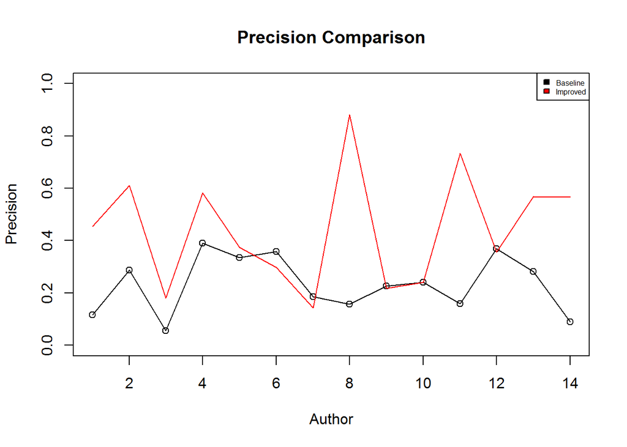

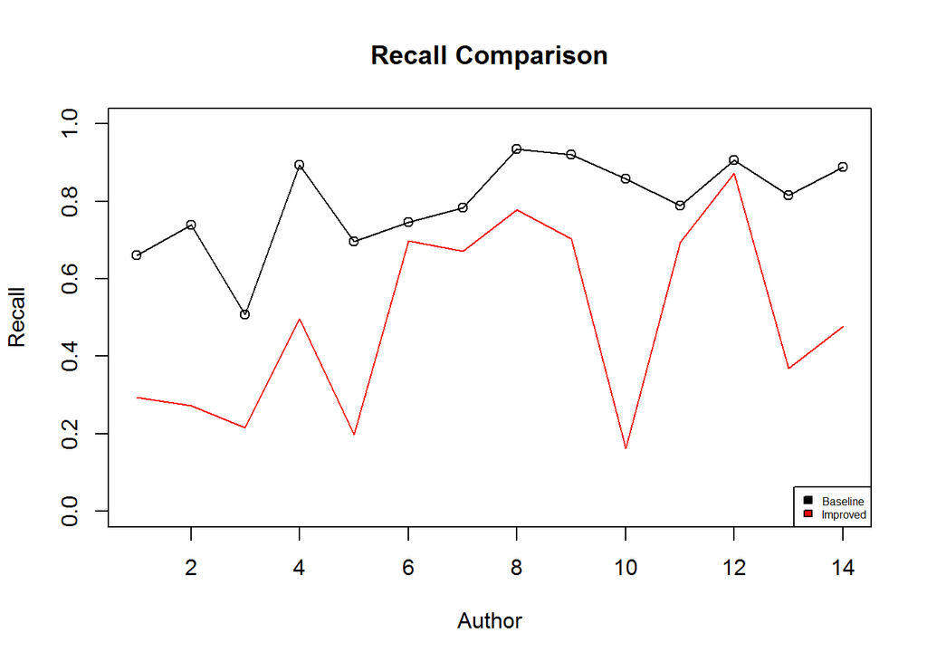

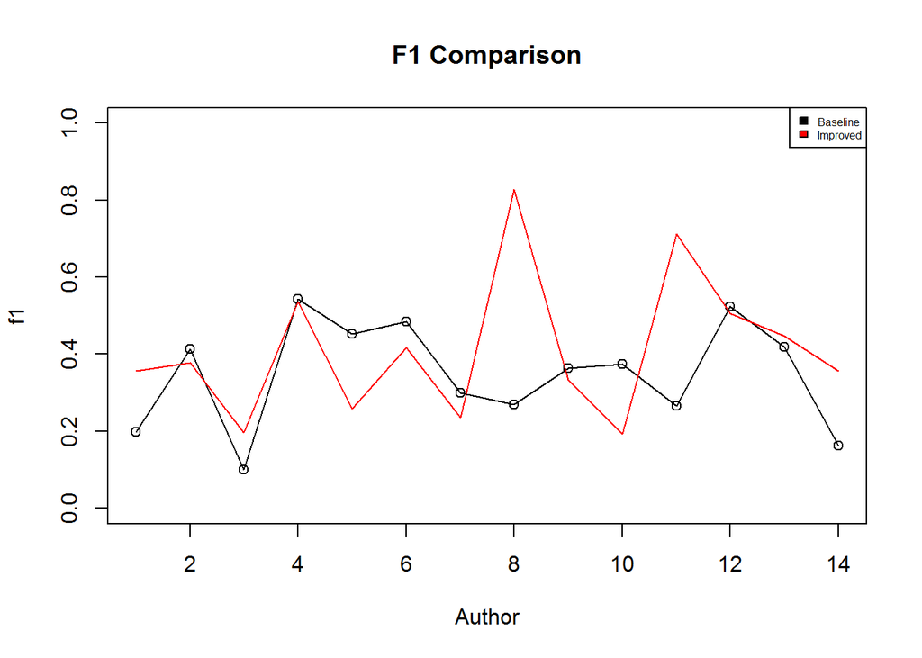

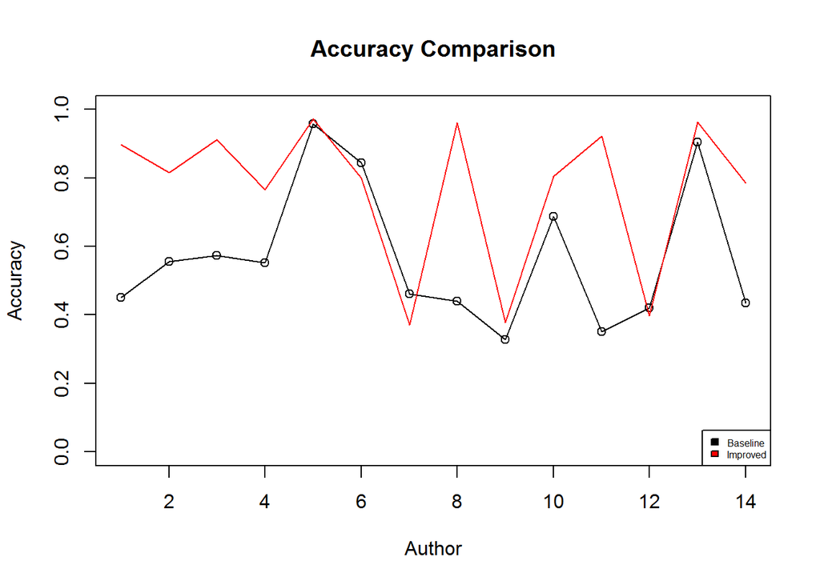

```r
new_result <- data.frame(baseline, improved_df)
new_result$Author <- rep(1:14)

plot(x=new_result$Author, y=new_result$precision, type = "o",
     ylim = c(0,1), xlab = "Author", ylab = "Precision", main = "Precision Comparison")
lines(x=new_result$Author, y=new_result$precision2, col="red")
legend("topright", legend = c("Baseline", "Improved"), fill = c("black", "red"), cex = 0.5)

plot(x=new_result$Author, y=new_result$recall, type = "o",
     ylim = c(0,1), xlab = "Author", ylab = "Recall", main = "Recall Comparison")
lines(x=new_result$Author, y=new_result$recall2, col="red")
legend("bottomright", legend = c("Baseline", "Improved"), fill = c("black", "red"), cex = 0.5)

plot(x=new_result$Author, y=new_result$f1, type = "o",
     ylim = c(0,1), xlab = "Author", ylab = "f1", main = "F1 Comparison")
lines(x=new_result$Author, y=new_result$f1_2, col="red")
legend("topright", legend = c("Baseline", "Improved"), fill = c("black", "red"), cex = 0.5)

plot(x=new_result$Author, y=new_result$accuracy, type = "o",
     ylim = c(0,1), xlab = "Author", ylab = "Accuracy", main = "Accuracy Comparison")
lines(x=new_result$Author, y=new_result$accuracy2, col="red")
legend("bottomright", legend = c("Baseline", "Improved"), fill = c("black", "red"), cex = 0.5)
```

### Observe the parameters for baseline

```r
new_result[,c("para_coauthor", "para_paper", "para_journal")]
```

```
##           para_coauthor para_paper para_journal
## AGupta       0.66694581 0.13711966   0.19593452
## AKumar       0.07316964 0.75770996   0.16912040
## CChen        0.86183001 0.11041953   0.02775046
## DJohnson     0.40805581 0.45310056   0.13884362
## JLee         0.50105991 0.08875476   0.41018533
## JMartin      0.12588646 0.82805248   0.04606106
## JRobinson    0.11356717 0.81837919   0.06805364
## JSmith       0.35238334 0.32355823   0.32405843
## KTanaka      0.32929501 0.39336006   0.27734493
## MBrown       0.31895039 0.38972184   0.29132777
## MJones       0.12539090 0.44557853   0.42903057
## MMiler       0.02875060 0.49266025   0.47858916
## SLee         0.31767252 0.27087225   0.41145523
## Ychen        0.22405100 0.52130931   0.25463969
```

### Observe the parameters for improved model

```r
new_result[,c("para_cos_coauthor2", "para_cos_paper2",
              "para_cos_journal2", "para_dis_coauthor2",
              "para_dist_paper2", "para_dist_journal2")]
```

```
##           para_cos_coauthor2 para_cos_paper2 para_cos_journal2
## AGupta             0.5387643       0.5955219        0.49818877
## AKumar             0.2483332       0.9688322        0.22767513
## CChen              4.8010815       0.9809583       -6.15158709
## DJohnson           0.3129241       0.5941206        0.20078260
## JLee               0.6158143       0.7722517        0.33496816
## JMartin            0.2766383       0.5269892        0.25031919
## JRobinson          0.2618366       0.6733229        0.07792393
## JSmith             0.3748055       0.3757711        0.40849130
## KTanaka            0.1864119       0.5053699        0.34581415
## MBrown             0.2542777       0.7873270        0.32488511
## MJones             0.1717627       0.5242650        0.42279711
## MMiler             0.1288000       0.2666000        0.27390000
## SLee               0.6925649       0.3312034        0.91390788
## Ychen              0.1288000       0.2666000        0.27390000
##           para_dis_coauthor2 para_dist_paper2 para_dist_journal2
## AGupta           -0.20488497      -0.37115848      -0.0564315618
## AKumar           -0.32304922      -0.11755828      -0.0042329723
## CChen            -1.14315505       2.34466352       0.1680387883
## DJohnson         -0.15671104       0.21408142      -0.1651976355
## JLee             -0.25866496       0.06216642      -0.5265355737
## JMartin          -0.18047951       0.12561974       0.0009131353
## JRobinson        -0.09486375       0.22903490      -0.1472545375
## JSmith           -0.14531404      -0.02781807       0.0140642635
## KTanaka          -0.17437456       0.17148650      -0.0347078881
## MBrown           -0.36968062       0.26980926      -0.2666184368
## MJones           -0.18557167       0.05132608       0.0154207988
## MMiler           -0.02600000       0.15400000       0.2027000000
## SLee             -0.18452920      -0.50203637      -0.2511106329
## Ychen            -0.02600000       0.15400000       0.2027000000
```